# Bike Rental Project_final

```
                                 *** Prediction of Bike Rental Count ***
```

```python
# Importing libraries for Data Cleaning and EDA:

import os
import numpy as np
import pandas as pd
import matplotlib as mlt
import matplotlib.pyplot as plt
import seaborn as sbn
%matplotlib inline
mlt.rcParams["patch.force_edgecolor"] = True
sbn.set_style("whitegrid")
sbn.set(font_scale=1.3)
```

```python
# Setting the working directory:
os.chdir("W:/DataScience/edWisor/Project")
```

```python
# Loading the data into pandas dataframe:
df = pd.read_csv("day.csv",sep=",")
```

```python
# Checking the head of data frame:
df.head()
```

|  | instant | dteday | season | yr | mnth | holiday | weekday | workingday | weathersit | temp | atemp | hum | windspeed | casual | registered | cnt |
| --- | --- | --- | --- | --- | --- | --- | --- | --- | --- | --- | --- | --- | --- | --- | --- | --- |
| 0 | 1 | 2011-01-01 | 1 | 0 | 1 | 0 | 6 | 0 | 2 | 0.344167 | 0.363625 | 0.805833 | 0.160446 | 331 | 654 | 985 |
| 1 | 2 | 2011-01-02 | 1 | 0 | 1 | 0 | 0 | 0 | 2 | 0.363478 | 0.353739 | 0.696087 | 0.248539 | 131 | 670 | 801 |
| 2 | 3 | 2011-01-03 | 1 | 0 | 1 | 0 | 1 | 1 | 1 | 0.196364 | 0.189405 | 0.437273 | 0.248309 | 120 | 1229 | 1349 |
| 3 | 4 | 2011-01-04 | 1 | 0 | 1 | 0 | 2 | 1 | 1 | 0.200000 | 0.212122 | 0.590435 | 0.160296 | 108 | 1454 | 1562 |
| 4 | 5 | 2011-01-05 | 1 | 0 | 1 | 0 | 3 | 1 | 1 | 0.226957 | 0.229270 | 0.436957 | 0.186900 | 82 | 1518 | 1600 |

# Data Pre Processing:

```python
# Checking the dimensions & datatype information of data:

df.info()
```

```
<class 'pandas.core.frame.DataFrame'>
RangeIndex: 731 entries, 0 to 730
Data columns (total 16 columns):
instant       731 non-null int64
dteday        731 non-null object
season        731 non-null int64
yr            731 non-null int64
mnth          731 non-null int64
holiday       731 non-null int64
weekday       731 non-null int64
workingday    731 non-null int64
weathersit    731 non-null int64
temp          731 non-null float64
atemp         731 non-null float64
hum           731 non-null float64
windspeed     731 non-null float64
casual        731 non-null int64
registered    731 non-null int64
cnt           731 non-null int64
dtypes: float64(4), int64(11), object(1)
memory usage: 91.5+ KB
```

*Missing Value Analysis:*

```python
# Checking for missing values in the data:

df.isnull().sum()
```

```
instant       0
dteday        0
season        0
yr            0
mnth          0
holiday       0
weekday       0
workingday    0
weathersit    0
temp          0
atemp         0
hum           0
windspeed     0
casual        0
registered    0
cnt           0
dtype: int64
```

So, the data does not contain any missing values. All the observations(records) are complete.

Columns, "casual" and "registered" are numerical variables, which need to be removed for the analysis because their sum directly gives the value of "cnt", the Target(Response) variable.

Column, "dteday" needs to be removed because all the information from the date variable is already included in the data such as: Year, Weekday.

Also, the "instant" column needs to be removed as it is just an added index column in the data file.

Columns, "season", "yr", "mnth", "holiday", "weekday", "working day", "weathersit" are categorical variables having integer encoded values.

Columns, "temp", "atemp", "hum", "windspeed" are numerical variables.

```python
# Dropping the unnecessary columns:

df = df.drop(columns=["instant", "dteday","casual","registered"],axis=1)
df.head()
```

|  | season | yr | mnth | holiday | weekday | workingday | weathersit | temp | atemp | hum | windspeed | cnt |
| --- | --- | --- | --- | --- | --- | --- | --- | --- | --- | --- | --- | --- |
| 0 | 1 | 0 | 1 | 0 | 6 | 0 | 2 | 0.344167 | 0.363625 | 0.805833 | 0.160446 | 985 |
| 1 | 1 | 0 | 1 | 0 | 0 | 0 | 2 | 0.363478 | 0.353739 | 0.696087 | 0.248539 | 801 |
| 2 | 1 | 0 | 1 | 0 | 1 | 1 | 1 | 0.196364 | 0.189405 | 0.437273 | 0.248309 | 1349 |
| 3 | 1 | 0 | 1 | 0 | 2 | 1 | 1 | 0.200000 | 0.212122 | 0.590435 | 0.160296 | 1562 |
| 4 | 1 | 0 | 1 | 0 | 3 | 1 | 1 | 0.226957 | 0.229270 | 0.436957 | 0.186900 | 1600 |

```python
# List of numerical variables:
num_var = ["temp","atemp","hum","windspeed","cnt"]

#List of categorical variables:
cat_var = ["season","yr","mnth","holiday","weekday","workingday","weathersit"]
```

```python
# Converting the variables in correct datatype:

for i in cat_var:
    df[i] = df[i].astype("category")
df.info()
```

```
<class 'pandas.core.frame.DataFrame'>
RangeIndex: 731 entries, 0 to 730
Data columns (total 12 columns):
season        731 non-null category
yr            731 non-null category
mnth          731 non-null category
holiday       731 non-null category
weekday       731 non-null category
workingday    731 non-null category
weathersit    731 non-null category
temp          731 non-null float64
atemp         731 non-null float64
hum           731 non-null float64
windspeed     731 non-null float64
cnt           731 non-null int64
dtypes: category(7), float64(4), int64(1)
memory usage: 35.0 KB
```

*Visualisations for exploring relationships b/w the variables:*

```
Text(0.5,1,' Mean Count v/s Season ')
```

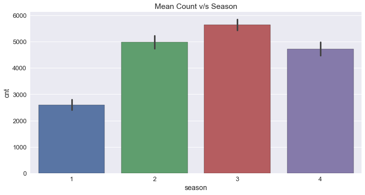

```python
# Barplot of Mean Count v/s Season

plt.figure(figsize=(12,6))
sbn.barplot(x="season", y="cnt", data=df)
plt.title(" Mean Count v/s Season ")
```

```
Text(0.5,1,' Mean Count v/s Weather Situation')
```

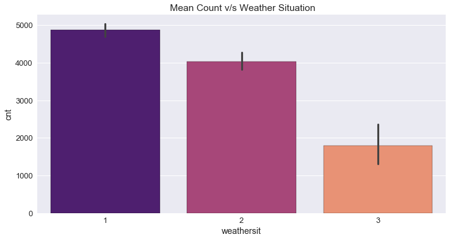

```python
# Barplot of Mean Count v/s Weather Situation:

plt.figure(figsize=(12,6))
sbn.barplot(x="weathersit",y='cnt',data=df,palette="magma")
plt.title(" Mean Count v/s Weather Situation")
```

```
Text(0.5,1,'Mean Count v/s Holiday')
```

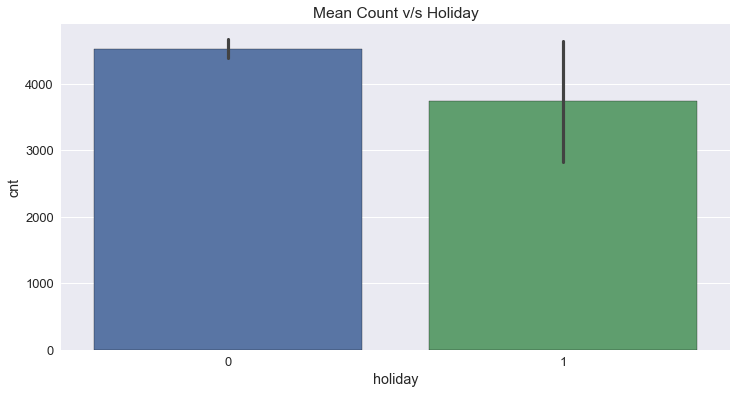

```python
# Barplot of Mean Count v/s Holiday

plt.figure(figsize=(12,6))
sbn.barplot(x="holiday",y="cnt",data=df)
plt.title("Mean Count v/s Holiday")
```

```
Text(0.5,1,'Mean Count v/s Weekday')
```

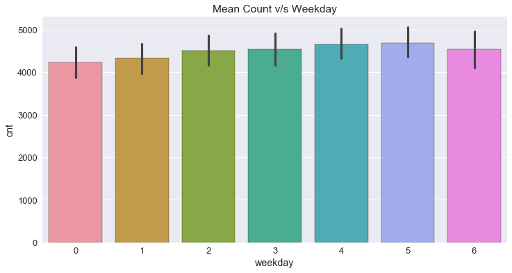

```python
# Barplot of Mean Count v/s Weekday:

plt.figure(figsize=(12,6))
sbn.barplot(x="weekday",y="cnt",data=df)
plt.title("Mean Count v/s Weekday")
```

```
Text(0.5,1,'Mean Count v/s WorkingDay')
```

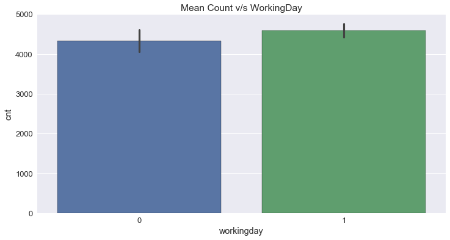

```python
# Barplot of Mean Count depending if the day is working or not:

plt.figure(figsize=(12,6))
sbn.barplot(x="workingday", y="cnt", data=df)
plt.title("Mean Count v/s WorkingDay")
```

```
Text(0.5,1,'Mean Count v/s Month')
```

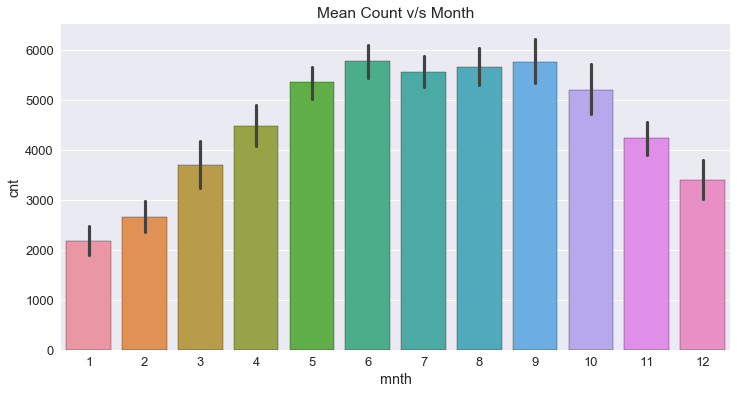

```python
# Barplot of Mean Count v/s Month:

plt.figure(figsize=(12,6))
sbn.barplot(x="mnth", y="cnt", data=df,)
plt.title("Mean Count v/s Month")
```

```
Text(0.5,1,'Total Count Distribution')
```

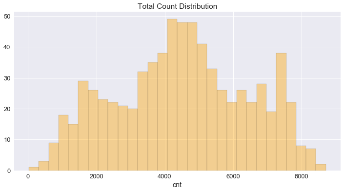

```python
# Distribution of Target variable:

plt.figure(figsize=(12,6))
sbn.distplot(df["cnt"],bins=30,color="orange",kde=False)
plt.title("Total Count Distribution")
```

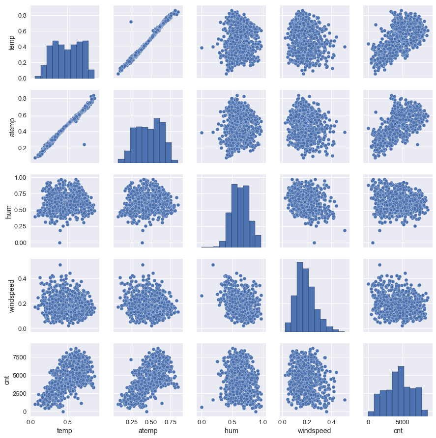

```python
# All the possible scatterplots of numerical variables in the dataset:

plt.figure(figsize=(12,6))
sbn.pairplot(df[num_var])
```

*Outlier Analysis:*

Checking for outliers in the numerical variables:

If there are some outliers found in the independent variables, for making an optimised model, it's best to remove these outliers.

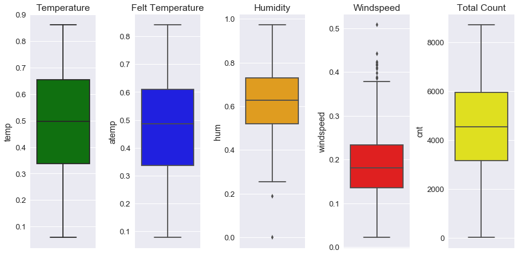

```python
# Making the figure and subplots for the boxplot visualisation:

fig, axes = plt.subplots(nrows=1, ncols=5,figsize=(12,6))

# Using Seaborn to create boxplots:

sbn.boxplot("temp", data=df, ax=axes[0], orient="v", color="green").set_title("Temperature")
sbn.boxplot("atemp", data=df, ax=axes[1], orient="v", color="blue").set_title("Felt Temperature")
sbn.boxplot("hum", data=df, ax=axes[2], orient="v", color="orange").set_title("Humidity")
sbn.boxplot("windspeed", data=df, ax=axes[3], orient="v", color="red").set_title("Windspeed")
sbn.boxplot("cnt", data=df, ax=axes[4], orient="v", color="yellow").set_title("Total Count")

# For better visibility of the labels:

plt.tight_layout()
```

```python
# Detect and delete outliers from data:

# List of numerical variables:
num_var = ["temp","atemp","hum","windspeed","cnt"]
for i in num_var:
    print("Variable: ",i)
    q75, q25 = np.percentile(df.loc[:,i], [75 ,25])
    iqr = q75 - q25
    min = q25 - (iqr*1.5)
    max = q75 + (iqr*1.5)
    print("Min Value: ",min)
    print("Max Value: ",max)
    print()
    df = df.drop(df[df.loc[:,i] < min].index)
    df = df.drop(df[df.loc[:,i] > max].index)
```

```
Variable:  temp
Min Value:  -0.14041600000000015
Max Value:  1.1329160000000003

Variable:  atemp
Min Value:  -0.06829675000000018
Max Value:  1.0147412500000002

Variable:  hum
Min Value:  0.20468725
Max Value:  1.0455212500000002

Variable:  windspeed
Min Value:  -0.012431000000000025
Max Value:  0.380585

Variable:  cnt
Min Value:  -1011.5
Max Value:  10256.5
```

*Feature Selection:*

```
Text(0.5,1,'Correlation Heatmap')
```

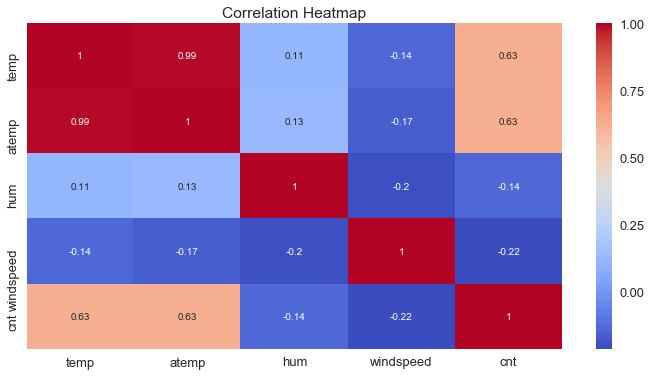

```python
# Correlation heatmap for numerical variables in the dataset:

plt.figure(figsize=(12,6))
sbn.heatmap(df[num_var].corr(), annot=True, cmap="coolwarm")
plt.title("Correlation Heatmap")
```

```python
# Dropping the column "atemp" from the dataset:

df = df.drop("atemp",axis=1)
```

```python
# Importing library for ANOVA test:

from statsmodels.formula.api import ols
import statsmodels.api as sm
```

Out of all the barplot visualisations, there was considerable difference in the means of groups in categorical variables, but the difference in group means of day of the week variable, "weekday" and "workingday" variable were very less. So let's do an ANOVA test on these variable because they variables might be the candidates for removal if p-value > 0.05.

```python
# ANOVA test for "weekday" categorical variable:

anova_week = ols("cnt ~ C(weekday)", data=df).fit()
print(anova_week.summary())
```

```
                            OLS Regression Results
==============================================================================
Dep. Variable:                    cnt   R-squared:                       0.007
Model:                            OLS   Adj. R-squared:                 -0.002
Method:                 Least Squares   F-statistic:                    0.7819
Date:                Wed, 28 Nov 2018   Prob (F-statistic):              0.584
Time:                        03:59:11   Log-Likelihood:                -6440.1
No. Observations:                 717   AIC:                         1.289e+04
Df Residuals:                     710   BIC:                         1.293e+04
Df Model:                           6
Covariance Type:            nonrobust
===================================================================================
                      coef    std err          t      P>|t|      [0.025      0.975]
-----------------------------------------------------------------------------------
Intercept        4252.8058    190.692     22.302      0.000    3878.418    4627.193
C(weekday)[T.1]   109.1255    270.339      0.404      0.687    -421.635     639.886
C(weekday)[T.2]   284.2233    269.679      1.054      0.292    -245.241     813.687
C(weekday)[T.3]   307.1165    269.679      1.139      0.255    -222.347     836.580
C(weekday)[T.4]   452.0952    271.011      1.668      0.096     -79.983     984.174
C(weekday)[T.5]   438.6602    269.679      1.627      0.104     -90.804     968.124
C(weekday)[T.6]   371.6157    270.339      1.375      0.170    -159.144     902.376
==============================================================================
Omnibus:                       64.523   Durbin-Watson:                   0.310
Prob(Omnibus):                  0.000   Jarque-Bera (JB):               20.906
Skew:                          -0.072   Prob(JB):                     2.89e-05
Kurtosis:                       2.176   Cond. No.                         7.85
==============================================================================

Warnings:
[1] Standard Errors assume that the covariance matrix of the errors is correctly specified.
```

```python
# Making an ANOVA table:

aov_table_week = sm.stats.anova_lm(anova_week, typ=2)
print(aov_table_week)
```

```
                  sum_sq     df         F    PR(>F)
C(weekday)  1.757122e+07    6.0  0.781896  0.584261
Residual    2.659257e+09  710.0       NaN       NaN
```

```python
# ANOVA test for "workingday" categorical variable:

anova_work = ols("cnt ~ C(workingday)", data=df).fit()
print(anova_work.summary())
```

```
                            OLS Regression Results
==============================================================================
Dep. Variable:                    cnt   R-squared:                       0.003
Model:                            OLS   Adj. R-squared:                  0.002
Method:                 Least Squares   F-statistic:                     2.276
Date:                Wed, 28 Nov 2018   Prob (F-statistic):              0.132
Time:                        04:00:34   Log-Likelihood:                -6441.4
No. Observations:                 717   AIC:                         1.289e+04
Df Residuals:                     715   BIC:                         1.290e+04
Df Model:                           1
Covariance Type:            nonrobust
======================================================================================
                         coef    std err          t      P>|t|      [0.025      0.975]
--------------------------------------------------------------------------------------
Intercept           4372.4115    128.503     34.026      0.000    4120.123    4624.700
C(workingday)[T.1]   234.2769    155.286      1.509      0.132     -70.594     539.147
==============================================================================
Omnibus:                       58.738   Durbin-Watson:                   0.318
Prob(Omnibus):                  0.000   Jarque-Bera (JB):               19.603
Skew:                          -0.045   Prob(JB):                     5.54e-05
Kurtosis:                       2.195   Cond. No.                         3.33
==============================================================================

Warnings:
[1] Standard Errors assume that the covariance matrix of the errors is correctly specified.
```

```python
# Making an ANOVA table:
aov_table_work= sm.stats.anova_lm(anova_work, typ=2)
print(aov_table_work)
```

```
                     sum_sq     df         F    PR(>F)
C(workingday)  8.494340e+06    1.0  2.276122  0.131822
Residual       2.668333e+09  715.0       NaN       NaN
```

```python
# Dropping the "weekday" & "workingday" variables because, the p-value is very high, F-statistic is low:
df = df.drop(["weekday","workingday"],axis=1)
```

```python
# Saving the cleaned data:
df.to_csv("day_cleaned.csv",index=False)
```

# Model Development:

```python
#Importing the required libraries:

from sklearn.model_selection import train_test_split
from sklearn.linear_model import LinearRegression
from sklearn.tree import DecisionTreeRegressor
from sklearn.ensemble import RandomForestRegressor
from sklearn import model_selection, preprocessing
from sklearn import metrics
```

```python
# Making separate dataframes of dependent & independent variables:

X = df.drop("cnt",axis=1)
y = df["cnt"]
```

```python
# Dummy variables for the categorical columns:

X = pd.get_dummies(data=X, columns=["season","yr","mnth","weathersit","holiday"],drop_first=True)
X.head()
```

|  | temp | hum | windspeed | season_2 | season_3 | season_4 | yr_1 | mnth_2 | mnth_3 | mnth_4 | ... | mnth_6 | mnth_7 | mnth_8 | mnth_9 | mnth_10 | mnth_11 | mnth_12 | weathersit_2 | weathersit_3 | holiday_1 |
| --- | --- | --- | --- | --- | --- | --- | --- | --- | --- | --- | --- | --- | --- | --- | --- | --- | --- | --- | --- | --- | --- |
| 0 | 0.344167 | 0.805833 | 0.160446 | 0 | 0 | 0 | 0 | 0 | 0 | 0 | ... | 0 | 0 | 0 | 0 | 0 | 0 | 0 | 1 | 0 | 0 |
| 1 | 0.363478 | 0.696087 | 0.248539 | 0 | 0 | 0 | 0 | 0 | 0 | 0 | ... | 0 | 0 | 0 | 0 | 0 | 0 | 0 | 1 | 0 | 0 |
| 2 | 0.196364 | 0.437273 | 0.248309 | 0 | 0 | 0 | 0 | 0 | 0 | 0 | ... | 0 | 0 | 0 | 0 | 0 | 0 | 0 | 0 | 0 | 0 |
| 3 | 0.200000 | 0.590435 | 0.160296 | 0 | 0 | 0 | 0 | 0 | 0 | 0 | ... | 0 | 0 | 0 | 0 | 0 | 0 | 0 | 0 | 0 | 0 |
| 4 | 0.226957 | 0.436957 | 0.186900 | 0 | 0 | 0 | 0 | 0 | 0 | 0 | ... | 0 | 0 | 0 | 0 | 0 | 0 | 0 | 0 | 0 | 0 |

5 rows × 21 columns

```python
# Splitting the data into training & testing set:

X_train,X_test,y_train,y_test = train_test_split(X, y, test_size=0.30, random_state= 1)
```

*Model Selection:*

```python
# Creating Linear Model object:

lm = LinearRegression()

# Fitting the training data:

lm.fit(X_train,y_train)
```

```
LinearRegression(copy_X=True, fit_intercept=True, n_jobs=1, normalize=False)
```

```python
# Predicting the values for test data:

pred_lm = lm.predict(X_test)
```

```
Text(0.5,1,' Linear Regression Results')
```

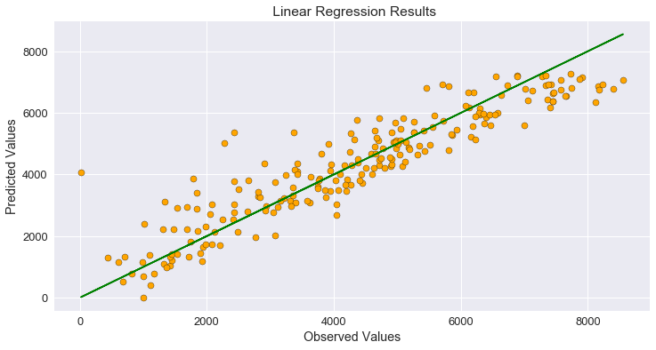

```python
# Plot of Predicted values v/s Observed Values:

plt.figure(figsize=(12,6))
plt.scatter(x=y_test, y=pred_lm, color="orange", s=50, edgecolor="black" )
plt.plot(y_test, y_test, color="green")
plt.xlabel("Observed Values")
plt.ylabel("Predicted Values")
plt.title(" Linear Regression Results")
```

```python
#Error Metrics:

print("Linear Regression: ")
print("The Accuracy Score is:", lm.score(X_test, y_test))
print("The Mean Absoulte Error[MAE] is:", metrics.mean_absolute_error(y_test, pred_lm))
print("The Mean Squared Error[MSE] is:", metrics.mean_squared_error(y_test, pred_lm))
```

```
Linear Regression:
The Accuracy Score is: 0.8456491401888867
The Mean Absoulte Error[MAE] is: 596.9928921191549
The Mean Squared Error[MSE] is: 639855.9691566614
```

```python
# Creating Decision Tree Regression Model object:

dt = DecisionTreeRegressor()

# Fitting the training data:

dt.fit(X_train,y_train)
```

```
DecisionTreeRegressor(criterion='mse', max_depth=None, max_features=None,
           max_leaf_nodes=None, min_impurity_decrease=0.0,
           min_impurity_split=None, min_samples_leaf=1,
           min_samples_split=2, min_weight_fraction_leaf=0.0,
           presort=False, random_state=None, splitter='best')
```

```python
# Predicitng the values of test dataset:

pred_dt = dt.predict(X_test)
```

```
Text(0.5,1,' Decision Tree Regression Results')
```

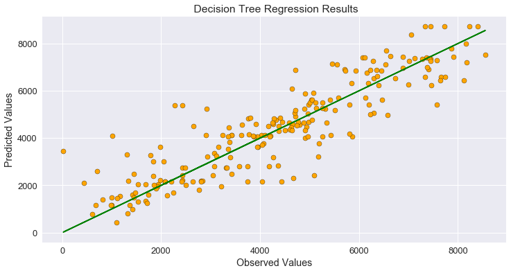

```python
# Plot of Predicted values v/s Observed Values:

plt.figure(figsize=(12,6))
plt.scatter(x=y_test, y=pred_dt, color="orange", s=50, edgecolor="black")
plt.plot(y_test, y_test, color="green")
plt.xlabel("Observed Values")
plt.ylabel("Predicted Values")
plt.title(" Decision Tree Regression Results")
```

```python
# Error Metrics:

print("Decision Tree: ")
print("The Accuracy Score is:\t\t", dt.score(X_test, y_test))
print("The Mean Absoulte Error[MAE] is:", metrics.mean_absolute_error(y_test, pred_dt))
print("The Mean Squared Error[MSE] is:\t", metrics.mean_squared_error(y_test, pred_dt))
```

```
Decision Tree:
The Accuracy Score is:		 0.7804340045784461
The Mean Absoulte Error[MAE] is: 699.1296296296297
The Mean Squared Error[MSE] is:	 910202.9814814815
```

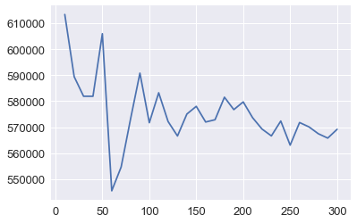

```python
# Random Forest Regression
# Using elbow method to determine the best value for "n_estimators"

error = []
k = np.linspace(10,300,30)
for i in k:
    rf_elbow = RandomForestRegressor(n_estimators= int(i))
    rf_elbow.fit(X_train,y_train)
    pred_elbow = rf_elbow.predict(X_test)
    mse = metrics.mean_squared_error(y_test, pred_elbow)
    error.append(mse)
plt.plot(k, error)
```

```python
# Getting the Optimum value for ntree parameter:
for i in range(0,len(k)):
    if(error[i]== np.array(error).min()):
        opt = k[i]

# Creating Random Forest Regression Model object:

rf = RandomForestRegressor(n_estimators= int(opt))

# Fitting the training data:

rf.fit(X_train,y_train)
```

```
RandomForestRegressor(bootstrap=True, criterion='mse', max_depth=None,
           max_features='auto', max_leaf_nodes=None,
           min_impurity_decrease=0.0, min_impurity_split=None,
           min_samples_leaf=1, min_samples_split=2,
           min_weight_fraction_leaf=0.0, n_estimators=60, n_jobs=1,
           oob_score=False, random_state=None, verbose=0, warm_start=False)
```

```python
# Predicitng the values of test dataset:

pred_rf = rf.predict(X_test)
```

```
Text(0.5,1,'Random Forest Regression Results')
```

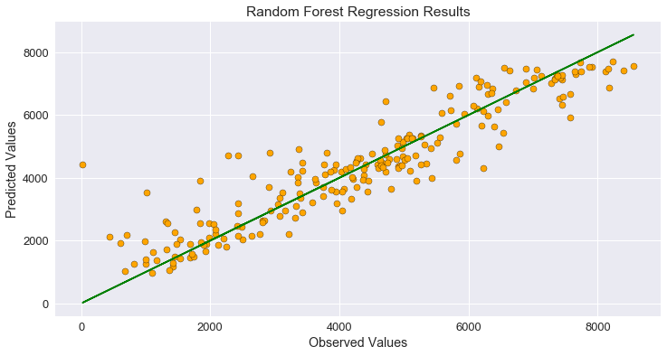

```python
# Plot of Predicted values v/s Observed Values:

plt.figure(figsize=(12,6))
plt.scatter(x=y_test, y=pred_rf, color="orange", s=50, edgecolor="black" )
plt.plot(y_test, y_test, color="green")
plt.xlabel("Observed Values")
plt.ylabel("Predicted Values")
plt.title("Random Forest Regression Results")
```

```python
# Error Metrics:

print("Random Forest Regression: ")
print("The Accuracy Score is:\t\t", rf.score(X_test, y_test))
print("The Mean Absoulte Error[MAE] is:", metrics.mean_absolute_error(y_test, pred_rf))
print("The Mean Squared Error[MSE] is:\t", metrics.mean_squared_error(y_test, pred_rf))
```

```
Random Forest Regression:
The Accuracy Score is:		 0.8558310836891019
The Mean Absoulte Error[MAE] is: 547.3833333333333
The Mean Squared Error[MSE] is:	 597647.0865226338
```

# Results:

Accuracy score and MSE(Mean Squared Error) of Random Forest Regression is the best out of all the tested models, so Random Forest Regression model is selected model for Prediction of Bike Rental Count.